# Chips_Showdown

output: html_document

## Score overview

17 people scored the chips on a 1 - 10 scale. Generally, the distribution of the scores looks somewhat normally distributed, albeit with some bias towards higher scores.

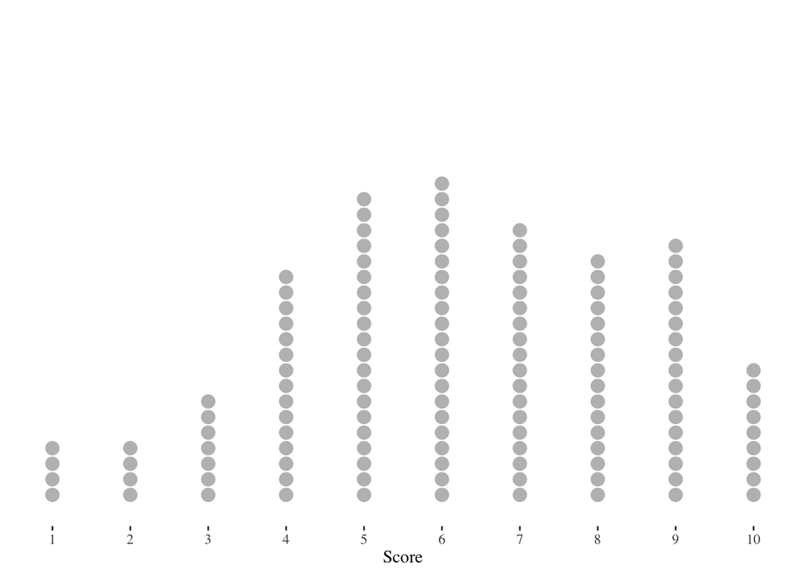

Some chips of course fare better than others. Overall, the highest scoring chips were “Tyrells Pepper & Salt” with a mean score of 8.06. The worst scoring chips were Kims Bølgechips (Chicken) which only had a mean score of 4.75. Maybe when it comes to chips, simplicity is good?

```
## # A tibble: 8 × 3
##   Flavour                       mean   var
##   <chr>                        <dbl> <dbl>
## 1 Tyrrels Pepper & salt         8.06  3.68
## 2 Truffle and Rosemary          7.47  3.39
## 3 Sourcream & Onion Linsechips  7.29  3.97
## 4 Bell Pepper Chips             6.12  2.92
## 5 Taffel Sourcream & Onion      5.62  1.98
## 6 Shrimp Chips                  5.19  4.43
## 7 Nachos w. Cheese Flavour      5.06  7.4
## 8 Kims Bølgechips (Chicken)     4.75  4.6
```

You can also see that some chips show more variance in their scores than others. The most consistently scored chips, “Taffel Sour Cream & Onion” receive a 4 or a 5 from most reviewers. This may be one of those chips that everyone likes and noone really hates or loves. On the other hand “Nachos w. Cheese Flavour” exhibited a huge variance and this flavour is clearly an aquired taste.

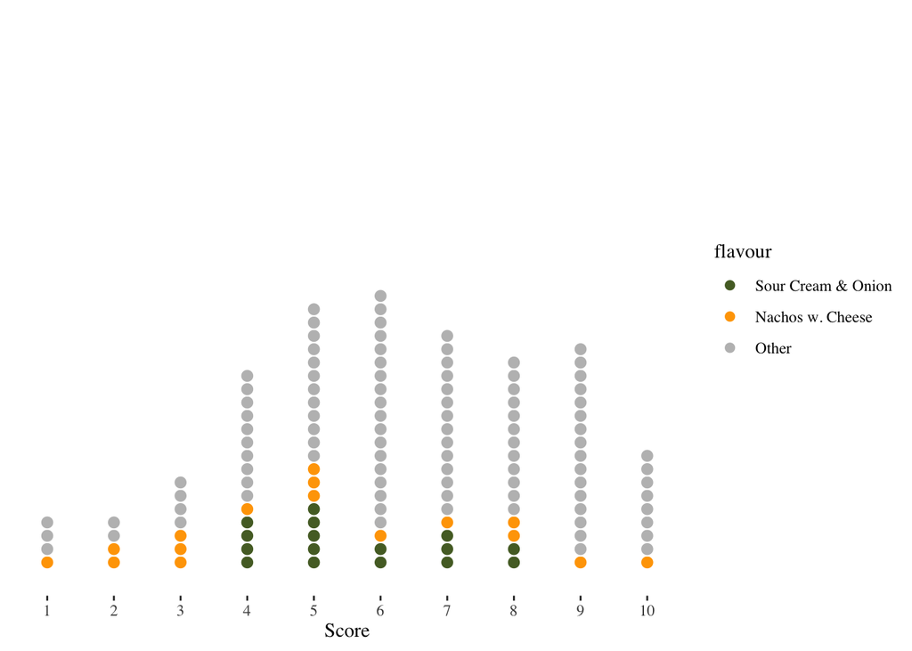

## Reviewer profiles

Instead of looking at the Chips in question let’s now turn our attention to the reviewers and their preferences. Below, we see two individuals who have similar tastes in chips. Apart from “Sour Cream and Onion Linsechips” (Lentil chips) these two individuals seem to like the same chips.

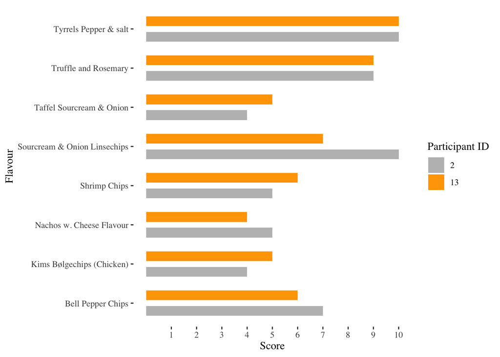

Let’s see which types of chips are most closely related in terms of reviewer ratings.

```
## Correlation computed with
## • Method: 'pearson'
## • Missing treated using: 'pairwise.complete.obs'
```

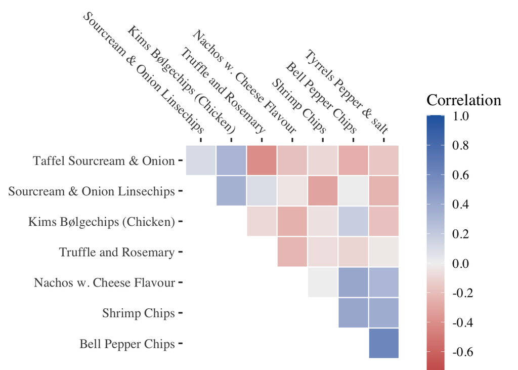

Here we see some interesting patterns. For example, “Truffle and Rosemary” doesn’t correlate well with many other flavours. And there is an especially negative correlation between “Truffle and Rosemary” and “Taffel Sour Cream & Onion”. (Insert theory about person archetypes here). Also, in spite of them being very different flavours, there seems to be a high correlation between “Bell Pepper Chips” and “Tyrrels Salt & Pepper”. Interestingly, there isn’t a strong correlation between the two most-liked chips, “Tyrrels Salt & Pepper” “Truffle & and Rosemary”. With a correlation coefficient near 0 lovers of one of two flavours do not seem to be aligned in their opinion of the other.